# Mapas del Departamento del Cauca

Authors

Juan Camilo Gutiérrez Martínez CC 1033486192

Maria Fernanda Calle Agudelo CC 1033428469

Jaider Castañeda Villa CC 1001015442

Published

July 1, 2025

# Introducción

El departamento del Cauca es una región de Colombia ubicada en el suroccidente del país, reconocida por su diversidad geográfica, cultural y étnica. Sin embargo, también enfrenta marcadas desigualdades sociales, económicas y de infraestructura entre sus municipios. Este informe presenta un análisis visual de tres variables clave: la distribución de la pobreza, el índice de desempeño fiscal y la distancia por carretera a su capital, Popayán. A través de mapas temáticos, se busca evidenciar estas diferencias territoriales y aportar elementos para una mejor comprensión del contexto regional.

# Objetivos

- **Identificación de brechas territoriales:** Detectar diferencias en las condiciones de vida entre municipios del Cauca según el NBI y su ubicación respecto a la capital.
- **Análisis de patrones espaciales de pobreza:** Explorar la posible relación entre la lejanía a Popayán y altos niveles de pobreza.
- **Evaluación del acceso equitativo a servicios:** Analizar desigualdades en el acceso a salud, educación e infraestructura según la distancia.
- **Visualización de desigualdad mediante mapas:** Representar gráficamente las condiciones socioeconómicas y geográficas del departamento.

# Metodología y Procedimientos

Para el desarrollo del análisis se utilizaron bases de datos externas, en su mayoría de fuentes oficiales. Las coordenadas geográficas de los municipios del departamento del Cauca fueron extraídas de un repositorio público disponible en Kaggle, en formato GeoJSON. Los indicadores utilizados —Índice de Necesidades Básicas Insatisfechas (NBI), el Índice de Desempeño Fiscal (IDF) y la distancia a la capital departamental— se obtuvieron de fuentes oficiales como el DANE, el Departamento Nacional de Planeación (DNP) y sitios especializados en cartografía y movilidad. En todos los casos se respetó la forma en que dichas entidades recolectaron, clasificaron y publicaron los datos, acogiendo sus criterios metodológicos.

Se descargaron las distintas bases de datos en formato Excel, CSV y GeoJSON. Posteriormente, se cargaron en el entorno de RStudio y se procesaron mediante herramientas del paquete dplyr para limpieza y transformación de datos. Con el uso de operaciones de unión (left_join) se integraron los indicadores al mapa base del Cauca, permitiendo así la visualización espacial mediante ggplot2. Este procedimiento permitió representar gráficamente los niveles del IDF y otros indicadores clave por municipio, facilitando su análisis comparativo y geográfico.

# Mapas

## Mapa del departamento

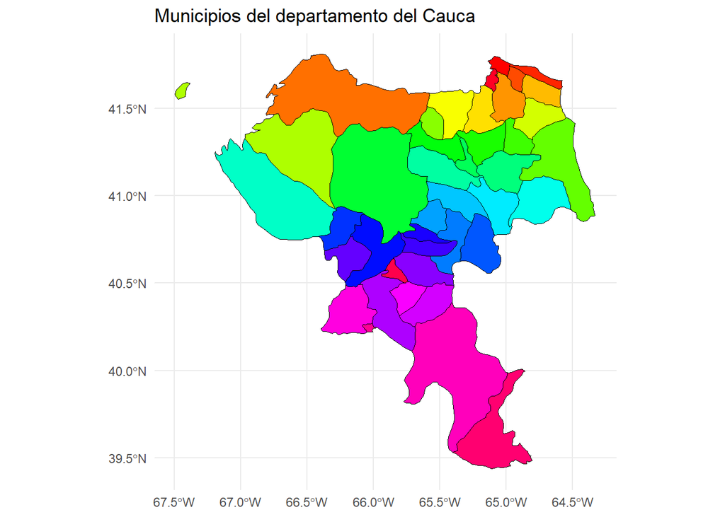

En total, el departamento del Cauca está conformado por **42 municipios**, cada uno representado en un color distinto en el mapa.

## Índice de Necesidades Básicas Insatisfechas (NBI)

El mapa muestra el Índice de Necesidades Básicas Insatisfechas (NBI) en los municipios del departamento del Cauca, reflejando los niveles de pobreza estructural en la región. A través de una escala de colores, se evidencia una fuerte desigualdad territorial: mientras algunos municipios tienen un NBI inferior al 20% (color verde), otros superan el 60% (color rojo), indicando condiciones críticas de pobreza.

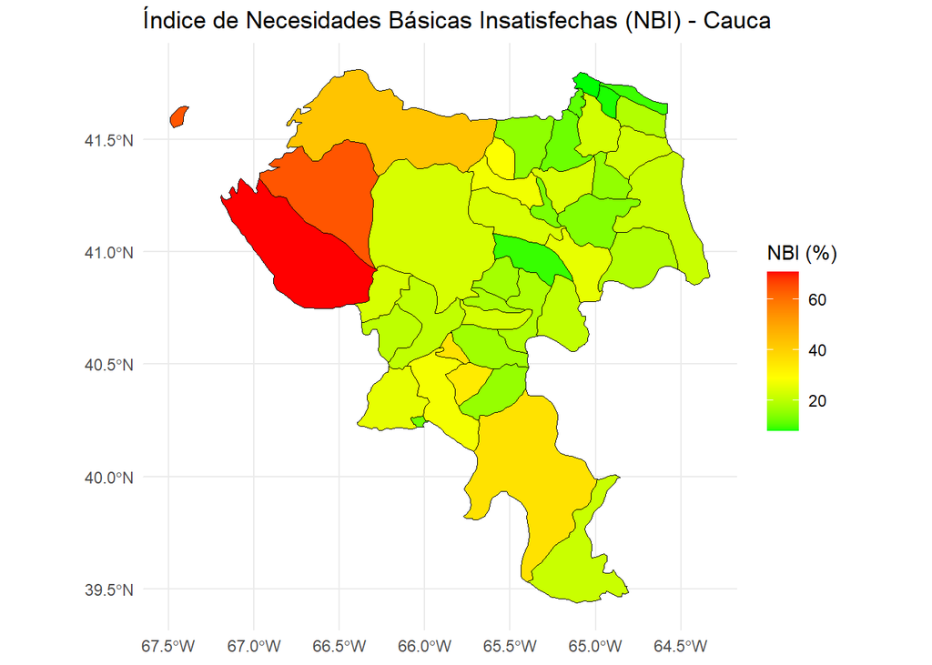

Las zonas más afectadas se ubican principalmente en el noroccidente del departamento, donde una alta proporción de la población carece de acceso adecuado a servicios básicos, vivienda y educación. En contraste, los municipios del centro y oriente muestran mejores condiciones de vida y mayor cobertura de necesidades básicas.

Este contraste territorial destaca la urgencia de intervenir en los municipios más vulnerables mediante políticas públicas focalizadas. El NBI es una herramienta clave para identificar brechas sociales y orientar la inversión hacia las zonas con mayores carencias.

## Índice de desempeño fiscal

El Índice de Desempeño Fiscal (IDF) de un municipio es una herramienta que mide la gestión financiera de una entidad territorial (municipio o departamento) en Colombia, evaluando su capacidad para generar ingresos propios, manejar sus deudas, invertir eficientemente y cumplir con las normativas fiscales. En esencia, refleja qué tan bien un municipio administra sus recursos económicos.

Para el ejercicio, nos vamos a enfocar en los municipios del departamento del Cauca, los datos se obtuvieron de la página web del Departamento Nacional de Planeación de Colombia, https://www.dnp.gov.co/LaEntidad_/subdireccion-general-descentralizacion-desarrollo-territorial/direccion-descentralizacion-fortalecimiento-fiscal/Paginas/informacion-fiscal-y-financiera.aspx actualizado al año 2023.

El mapa muestra la clasificación de cada municipio del Cauca en base a su índice de desempeño fiscal. En la documentación oficial la clasificación está definida así:

- 1. Deterioro (<40)
- 2. Riesgo (>=40 y <60)
- 3. Vulnerable (>=60 y <70)
- 4. Solvente (>=70 y <80)
- 5. Sostenible (>=80)

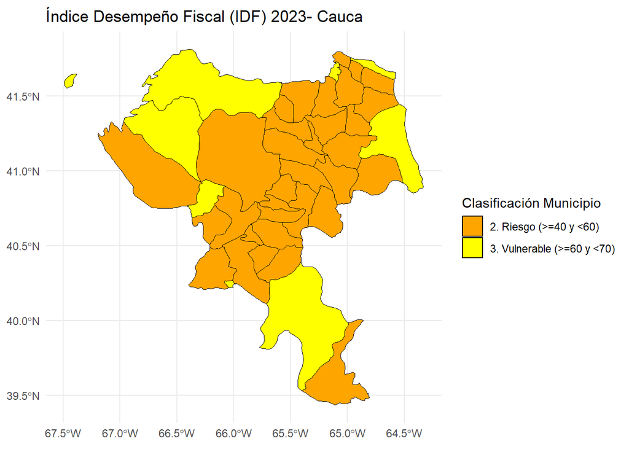

El mapa anterior nos da un vistazo general de las condiciones del departamento del Cauca respecto al IDF, lo primero que se ve es que hay cierta homogeneidad, pues solo hay municipios de dos tipos, en riesgo y vulnerables. Premisa que nos lleva a pensar que el Cauca tiene ciertas limitaciones ecónomicas en sus municipios y no muestran un buen desempeño en los parámetros utilizados para calcular el IDF.

Vamos a hacer un análisis más profundo:

```
   Min. 1st Qu.  Median    Mean 3rd Qu.    Max.
  41.65   51.07   54.91   55.39   59.24   69.46
```

Ahora miremos la desviación estándar:

```
[1] 6.740795
```

La desviación estándar es baja, lo que reafirma la afirmación de que en cuanto al IDF el departamento del Cauca es muy homogéneo.

Estos son los cincos municipios con más alto IDF:

```
# A tibble: 5 × 4
  Código Municipio      `Nuevo IDF` Rango
  <chr>  <chr>                <dbl> <chr>
1 19418  LOPEZ DE MICAY        69.5 3. Vulnerable (>=60 y <70)
2 19300  GUACHENE              68.9 3. Vulnerable (>=60 y <70)
3 19809  TIMBIQUI              67.8 3. Vulnerable (>=60 y <70)
4 19290  FLORENCIA             67.7 3. Vulnerable (>=60 y <70)
5 19455  MIRANDA               64.8 3. Vulnerable (>=60 y <70)
```

El municipio Lopez De Micay tiene el índice de desempeño fiscal más alto del departamento.

Estos son los cincos municipios con más bajo IDF:

```
# A tibble: 5 × 4
  Código Municipio        `Nuevo IDF` Rango
  <chr>  <chr>                  <dbl> <chr>
1 19743  SILVIA                  41.6 2. Riesgo (>=40 y <60)
2 19137  CALDONO                 45.0 2. Riesgo (>=40 y <60)
3 19532  PATIA (EL BORDO)        45.9 2. Riesgo (>=40 y <60)
4 19450  MERCADERES              46.2 2. Riesgo (>=40 y <60)
5 19573  PUERTO TEJADA           47.6 2. Riesgo (>=40 y <60)
```

El municipio de Silvia tiene el IDF más bajo y se encuentra en el límite a convertirse un municipio en deteriorio. (menor a 40).